[figure not shown]

[Entreprise](https://www.economag.fr/business/)

# Les secrets des diamants 1 carat : comprendre leur valeur et leur prix

17 janvier 2025

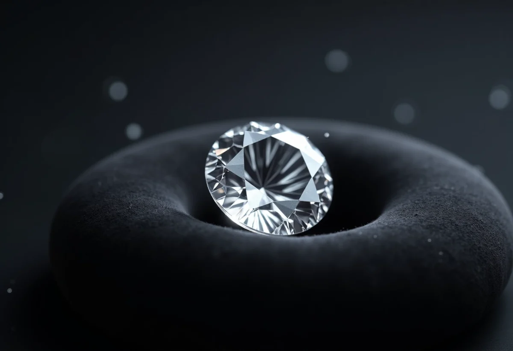

Les diamants d’un carat suscitent toujours fascination et admiration. Ces petites merveilles de la nature, formées sous une pression extrême pendant des millions d’années, incarnent luxe et raffinement. Les bijoutiers et les amateurs avertis savent que la valeur d’un diamant ne se limite pas à sa taille ou à son poids.

Comprendre le prix de ces joyaux nécessite de prendre en compte plusieurs facteurs essentiels. La pureté, la couleur, la taille et la coupe influencent grandement leur valeur sur le marché. Chacun de ces critères contribue à la brillance unique et à l’éclat incomparable d’un diamant d’un carat.

Plan de l'article

- Comment évaluer la valeur d’un diamant de 1 carat ?
  - Carat
  - Cut
  - Color
  - Clarity
- Les facteurs influençant le prix d’un diamant de 1 carat
  - Certificat de gemmologie
  - Demande du marché
  - Origine du diamant
- Prix indicatif et tendances du marché pour les diamants de 1 carat
  - Fourchette de prix
  - Tendances actuelles
  - Impact des nouvelles technologies

## Comment évaluer la valeur d’un diamant de 1 carat ?

Évaluer la valeur d’un diamant de 1 carat repose sur les célèbres 4C : **Carat**, **Cut**, **Color** et **Clarity**. Chacun de ces critères joue un rôle fondamental dans la détermination de la qualité et, par extension, du prix du diamant.

### Carat

Le carat est l’unité de mesure du poids des diamants. Un carat équivaut à 0,2 gramme. Si le poids est un facteur déterminant, il n’est pas le seul à influencer la valeur. Un diamant de 1 carat peut varier significativement en prix selon ses autres caractéristiques.

### Cut

La qualité de la taille, ou cut, impacte directement la brillance du diamant. Une taille excellente permet à la lumière de se refléter et de se réfracter de manière optimale, offrant une brillance éclatante. Une mauvaise taille peut diminuer la valeur, même si les autres critères sont excellents.

### Color

La couleur, classée sur une échelle allant de D (incolore) à Z (teinte jaune), joue aussi un rôle prépondérant. Les diamants incolores sont les plus rares et, par conséquent, les plus précieux. La présence de teintes visibles réduit généralement la valeur.

### Clarity

La pureté, ou clarity, évalue la présence d’inclusions ou de défauts internes. Ces imperfections, invisibles à l’œil nu, peuvent pourtant affecter la qualité et la valeur du diamant. Les diamants sans inclusions, dits ‘flawless’, sont extrêmement rares et chers.

- **Carat** : poids du diamant en carats
- **Cut** : qualité de la taille
- **Color** : couleur du diamant
- **Clarity** : pureté du diamant

La combinaison de ces critères permet d’évaluer précisément la valeur d’un diamant de 1 carat. Considérez chaque facteur avec attention pour une évaluation juste et pertinente.

## Les facteurs influençant le prix d’un diamant de 1 carat

Plusieurs éléments déterminent le prix d’un diamant de 1 carat. Au-delà des 4C, un autre facteur fondamental est le **certificat** de gemmologie, qui atteste des caractéristiques du diamant.

### Certificat de gemmologie

Les certificats sont délivrés par plusieurs laboratoires reconnus :

- **GIA** (Gemological Institute of America)
- **LFG** (Laboratoire Français de Gemmologie)
- **IGI** (International Gemological Institute)
- **HRD** (Hoge Raad voor Diamant)
- **AIG** (Antwerp International Gemological Laboratories)

Ces certificats garantissent la véracité des informations concernant la taille, la couleur, la pureté et le poids du diamant. Un diamant certifié par le GIA, par exemple, jouira d’une meilleure réputation sur le marché, impactant directement son prix.

### Demande du marché

La demande joue aussi un rôle fondamental. Les tendances du marché, influencées par les goûts et les préférences des consommateurs, peuvent faire varier le prix des diamants de 1 carat. Les périodes de haute demande, comme les fêtes de fin d’année ou la saison des mariages, voient souvent une augmentation des prix.

### Origine du diamant

L’origine du diamant peut aussi influencer le prix. Les diamants provenant de zones éthiques et respectant les normes du processus de Kimberley, qui vise à éliminer le commerce des diamants de conflits, sont généralement plus prisés. Les consommateurs sont de plus en plus sensibles à ces questions éthiques, ce qui se reflète dans les prix.

Ces multiples facteurs combinés déterminent la valeur et le prix final d’un diamant de 1 carat.

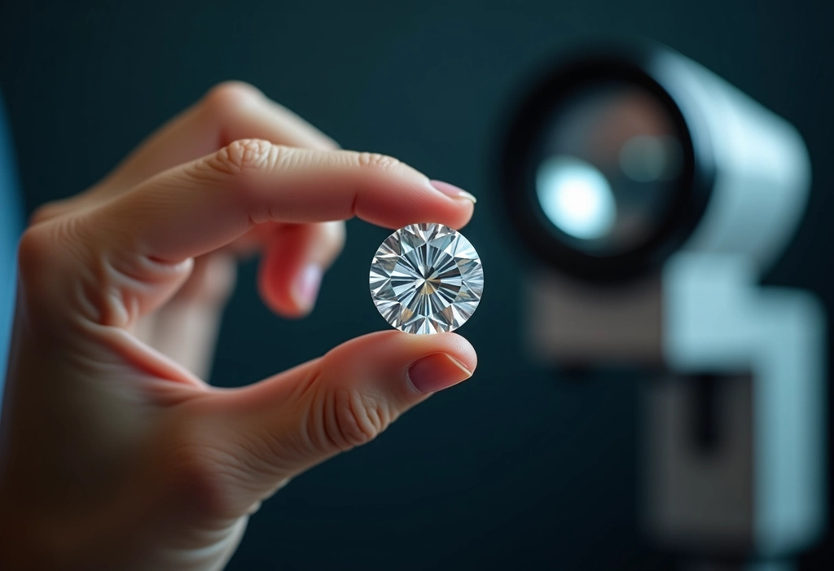

## Prix indicatif et tendances du marché pour les diamants de 1 carat

Le marché des diamants de 1 carat est influencé par plusieurs facteurs, dont l’offre et la demande, ainsi que les tendances de la mode et de la joaillerie. En général, le prix d’un diamant de 1 carat oscille entre **4 000 et 12 000 euros**, selon ses caractéristiques spécifiques.

### Fourchette de prix

- Diamant de qualité moyenne (bonne couleur et pureté) : 4 000 – 6 000 euros
- Diamant de haute qualité (très bonne couleur et pureté) : 6 000 – 8 000 euros
- Diamant exceptionnel (incolore et sans inclusion) : 8 000 – 12 000 euros

### Tendances actuelles

Les maisons de haute joaillerie comme **Boucheron** et **Van Cleef & Arpels** dictent souvent les tendances du marché. Actuellement, la demande pour des diamants éthiques et certifiés, notamment par le **GIA**, est en hausse. Les consommateurs privilégient de plus en plus des diamants traçables, certifiés par des laboratoires de renom comme le **LFG** ou l’**IGI**.

### Impact des nouvelles technologies

Les avancées technologiques, notamment les diamants synthétiques, commencent à influencer le marché. Bien que ces derniers ne puissent rivaliser en termes de prestige avec les diamants naturels, ils représentent une option économique et respectueuse de l’environnement. Les effets sur le prix des diamants naturels restent à surveiller.

Ces éléments combinés dessinent une image dynamique du marché des diamants de 1 carat, où les prix et les tendances évoluent en fonction des préférences des consommateurs et des innovations technologiques.